[figure not shown]

# 2da Semana (11/11/2020) - Funciones y Límites con Python

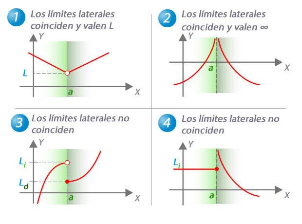

## Learn How to Write Markdown & LaTeX in The Jupyter Notebook

https://towardsdatascience.com/write-markdown-latex-in-the-jupyter-notebook-10985edb91fd

#### Markdown es el formato que nos permite escribir en el documento, en éste caso Jupyter Notebook.

#### Utiliza un leguaje de texto llamado LaTeX.

#### EL enlace conduce a un tutorial básico.

#### Verán que es muy útil dado que nos permite escribir fórmulas y símbolos matemáticos.

## Introducción

El [Cálculo](https://es.wikipedia.org/wiki/C%C3%A1lculo_infinitesimal) es una rama muy importante de la [Matemática](https://es.wikipedia.org/wiki/Matem%C3%A1tica) moderna; tiene profundas raíces en problemas físicos y gran parte de su potencia y belleza derivan de la variedad de sus aplicaciones. Las subramas conocidas como [Cálculo integral](https://es.wikipedia.org/wiki/Integraci%C3%B3n) y [Cálculo diferencial](https://es.wikipedia.org/wiki/C%C3%A1lculo_diferencial) son instrumentos poderosos para atacar múltiples problemas que surgen en [Física](https://es.wikipedia.org/wiki/F%C3%ADsica), [Astronomía](https://es.wikipedia.org/wiki/Astronom%C3%ADa), [Ingeniería](https://es.wikipedia.org/wiki/Ingenier%C3%ADa), [Química](https://es.wikipedia.org/wiki/Qu%C3%ADmica), [Geología](https://es.wikipedia.org/wiki/Geolog%C3%ADa), [Biología](https://es.wikipedia.org/wiki/Biolog%C3%ADa), y en otros campos de las ciencias. El [Cálculo](https://es.wikipedia.org/wiki/C%C3%A1lculo_infinitesimal) no sólo es un instrumento técnico, sino que contiene una colección de ideas fascinantes y atrayentes que han ocupado el pensamiento humano durante cientos de años. Estas ideas están relacionadas con la velocidad, el área, el volumen, la razón de crecimiento, la tangente a una línea, y demás.

### Historia

El origen del [Cálculo](https://es.wikipedia.org/wiki/C%C3%A1lculo_infinitesimal) se remonta a más de 2300 años, cuando los griegos intentaban resolver el problema del [área](https://es.wikipedia.org/wiki/%C3%81rea) ideando el procedimiento que llamaron [método de exhaución](https://es.wikipedia.org/wiki/M%C3%A9todo_exhaustivo). La idea esencial de este método consiste en intentar determinar el [área](https://es.wikipedia.org/wiki/%C3%81rea) de una región por medio de aproximaciones utilizando regiones [poligonales](https://es.wikipedia.org/wiki/Pol%C3%ADgono) cuya [área](https://es.wikipedia.org/wiki/%C3%81rea) sea más fácil de calcular, la idea es continuar con el proceso aumentando los lados de los [polígonos](https://es.wikipedia.org/wiki/Pol%C3%ADgono) hasta llegar a la mejor aproximación posible de la región que queremos determinar. Este método fue usado satisfactoriamente por [Arquímedes](https://es.wikipedia.org/wiki/Arqu%C3%ADmedes) (287-212 A.C.) para hallar fórmulas exactas de las áreas del [círculo](https://es.wikipedia.org/wiki/C%C3%ADrculo) y de algunas otras figuras especiales. En la siguiente figura podemos ver al [método de exhaución](https://es.wikipedia.org/wiki/M%C3%A9todo_exhaustivo) aplicado para determinar el área del [círculo](https://es.wikipedia.org/wiki/C%C3%ADrculo).

[figure not shown]

Desde [Arquímedes](https://es.wikipedia.org/wiki/Arqu%C3%ADmedes), gradualmente, el [método de exhaución](https://es.wikipedia.org/wiki/M%C3%A9todo_exhaustivo) fue transformándose en lo que hoy se conoce como [Cálculo integral](https://es.wikipedia.org/wiki/Integraci%C3%B3n), nueva y potente disciplina que, como ya mencionamos, tiene numerosas aplicaciones no sólo en problemas relativos a áreas y volúmenes, sino también en problemas de otras ciencias. El [Cálculo integral](https://es.wikipedia.org/wiki/Integraci%C3%B3n), que mantiene alguno de los caracteres originales del [método de exhaución](https://es.wikipedia.org/wiki/M%C3%A9todo_exhaustivo), recibió su mayor impulso en el siglo XVII, debido a los esfuerzos de [Isaac Newton](https://es.wikipedia.org/wiki/Isaac_Newton) (1642-1727) y [Gottfried Leibniz](https://es.wikipedia.org/wiki/Gottfried_Leibniz) (1646-1716), y su desarrollo continuó durante el siglo XIX, hasta que [Augustin-Louis Cauchy](https://es.wikipedia.org/wiki/Augustin_Louis_Cauchy) (1789-1857) y [Bernhard Riemann](https://es.wikipedia.org/wiki/Bernhard_Riemann) (1826-1866) le dieron una base [matemática](https://es.wikipedia.org/wiki/Matem%C3%A1tica) firme.

# Funciones

Las [Funciones](https://es.wikipedia.org/wiki/Funci%C3%B3n_matem%C3%A1tica) son los objetos fundamentales con los que tratamos en el [Cálculo](https://es.wikipedia.org/wiki/C%C3%A1lculo_infinitesimal). Las mismas pueden ser representadas de diferentes maneras: por una [ecuación](https://es.wikipedia.org/wiki/Ecuaci%C3%B3n), en una tabla, por un gráfico, o en palabras. Se utilizan principalmente como modelos matemáticos para representar fenómenos del mundo real.

La palabra *[Función](https://es.wikipedia.org/wiki/Funci%C3%B3n_matem%C3%A1tica)* fue introducida en las [Matemáticas](https://es.wikipedia.org/wiki/Matem%C3%A1tica) por Leibniz, quien utilizaba este término para designar cierto tipo de fórmulas matemáticas. Una *[Función](https://es.wikipedia.org/wiki/Funci%C3%B3n_matem%C3%A1tica)* surge cada vez que una cantidad depende de otra. Más precisamente la definición de *[Función](https://es.wikipedia.org/wiki/Funci%C3%B3n_matem%C3%A1tica)* es esencialmente la siguiente: Dados dos conjuntos de objetos, el conjunto X y el conjunto Y, una *[Función](https://es.wikipedia.org/wiki/Funci%C3%B3n_matem%C3%A1tica)* es una regla que asocia a cada objeto de X, uno y sólo un, objeto en Y. El conjunto X se denomina el *dominio* de la *[Función](https://es.wikipedia.org/wiki/Funci%C3%B3n_matem%C3%A1tica)*. Los objetos de Y, asociados con los objetos en X forman otro conjunto denominado el *recorrido* de la *[Función](https://es.wikipedia.org/wiki/Funci%C3%B3n_matem%C3%A1tica)*. Generalmente se utilizan las letras $f, g, h, G$ y $H$ para designarlas. Si $f$ es una función dada y $x$ es un objeto de su dominio, la notación $f(x)$ se utiliza para designar el objeto que en el recorrido corresponde a $x$, en la *[Función](https://es.wikipedia.org/wiki/Funci%C3%B3n_matem%C3%A1tica)* $f$, y se denomina el valor de la función $f$ en $x$. El símbolo $f(x)$ se lee, «f de x».

Muchas veces resulta útil pensar en una *[Función](https://es.wikipedia.org/wiki/Funci%C3%B3n_matem%C3%A1tica)* como si fuera una máquina. Si $x$ está en el dominio de la función $f$, entonces cuando $x$ entra en la máquina, se acepta como una entrada y la máquina produce una salida $f(x)$ de acuerdo a la regla de la función. Así, podemos pensar al *dominio* como el conjunto de todas las entradas posibles y al *recorrido* como el conjunto de todas las salidas posibles.

El método más común para la visualización de una *[Función](https://es.wikipedia.org/wiki/Funci%C3%B3n_matem%C3%A1tica)* es su [gráfica](https://es.wikipedia.org/wiki/Gr%C3%A1fica_de_una_funci%C3%B3n). Si $f$ es una *[Función](https://es.wikipedia.org/wiki/Funci%C3%B3n_matem%C3%A1tica)* con dominio $D$, a continuación, su [gráfica](https://es.wikipedia.org/wiki/Gr%C3%A1fica_de_una_funci%C3%B3n) es el conjunto de [pares ordenados](https://es.wikipedia.org/wiki/Pares_ordenados).

$$\{(x, f(x)) \mid x \in D \} $$

Aquí debemos tener en cuenta que el par $(x, f(x))$, es un par *entrada-salida*, el valor de $x$ representa el valor de entrada, mientras que el valor de $f(x)$ representa la salida de la *[Función](https://es.wikipedia.org/wiki/Funci%C3%B3n_matem%C3%A1tica)*. En otras palabras, la [gráfica](https://es.wikipedia.org/wiki/Gr%C3%A1fica_de_una_funci%C3%B3n) de $f$ se compone de todos puntos $(x, y)$ en el plano de coordenadas tal que $y=f(x)$ y $x$ está en el *dominio* de $f$. La [gráfica](https://es.wikipedia.org/wiki/Gr%C3%A1fica_de_una_funci%C3%B3n) de una *[Función](https://es.wikipedia.org/wiki/Funci%C3%B3n_matem%C3%A1tica)* $f$ nos da una imagen útil del comportamiento o la "historia de vida" de la misma.

[figure not shown]

### Funciones con Python

Para definir las [Funciones](https://es.wikipedia.org/wiki/Funci%C3%B3n_matem%C3%A1tica) en [Python](https://www.python.org/) utilizamos la instrucción `def`. Así por ejemplo si quisiéramos definir a la *[Función](https://es.wikipedia.org/wiki/Funci%C3%B3n_matem%C3%A1tica)* $f(x) = \sqrt{x + 2}$ dentro de [Python](https://www.python.org/), lo podríamos hacer de la siguiente forma:

```python
# Un comentario se definie anteponiendo el símbolo #
# importo la librería numpy
import numpy as np

#defino la función f que:
#recibe como parámetro o variable de entrada x y
#retorna la raiz cuadrada de la suma de x mas 2
def f(x):
    return np.sqrt(x + 2)
```

En este ejemplo, primero estamos importando la librería [numpy](https://www.numpy.org/), para trabajar más fácilmente con vectores, los cuales simplifican los cálculos numéricos. Luego utilizamos la instrucción `def` para definir la función, que este caso se va a llamar f y va a tener como único parámetro al objeto x.

Esta función nos va a devolver el valor de la raíz cuadrada de $x + 2$. Ahora, si por ejemplo quisiéramos saber los valores de la función $f(x)$ para los $x, -2, -1, 0, 2, 4$ y $6$. podríamos invocar a esta función de la siguiente manera:

```python
#Defino un vector con 6 valores que tomará x durante la ejecución de f(x)
x = np.array([-2, -1, 0, 2, 4, 6])  # Creando el vector de valores de x
#asigno a y el resultado de f(x)
y = f(x)
#muestro los valores calculados (con cada x) de cada y
y
```

```
array([0.        , 1.        , 1.41421356, 2.        , 2.44948974,
       2.82842712])
```

Si quisiéramos verlo en forma de tabla, podemos ayudarnos de la librería [pandas](https://pandas.pydata.org/) y su [estructura de datos](https://es.wikipedia.org/wiki/Estructura_de_datos) [DataFrame](https://pandas.pydata.org/pandas-docs/stable/generated/pandas.DataFrame.html), la cual tiene una forma tabular.

```python
#importo la librería pandas con alias pd
import pandas as pd
#asigno a tabla un Dataframe (ya veremos que es) con los valores de cada x e y correspondiente en las filas
tabla = pd.DataFrame( list(zip(x, y)), columns=['x', 'f(x)'] )
tabla
```

|  | x | f(x) |
| --- | --- | --- |
| 0 | -2 | 0.000000 |
| 1 | -1 | 1.000000 |
| 2 | 0 | 1.414214 |
| 3 | 2 | 2.000000 |
| 4 | 4 | 2.449490 |
| 5 | 6 | 2.828427 |

Por último, si quisiéramos graficar funciones con [Python](https://www.python.org/), podemos utilizar la librería [Matplotlib](https://matplotlib.org/), y pasarle los valores de $x$ e $y$ al método `plot` del objeto `pyplot`.

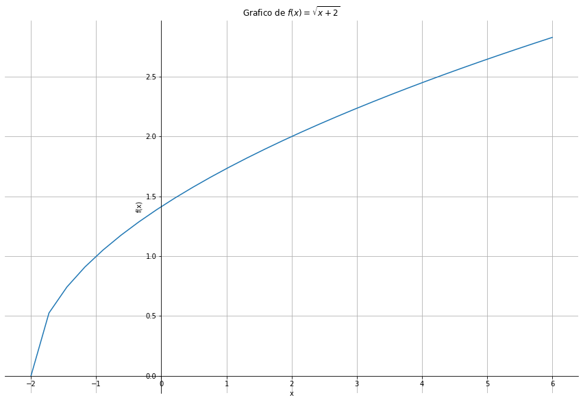

```python
%matplotlib inline

import matplotlib.pyplot as plt

def move_spines():
    """Esta funcion divide pone al eje y en el valor
    0 de x para dividir claramente los valores positivos y
    negativos."""
    fix, ax = plt.subplots(figsize=(15,10))
    for spine in ["left", "bottom"]:
        ax.spines[spine].set_position("zero")

    for spine in ["right", "top"]:
        ax.spines[spine].set_color("none")

    return ax

x = np.linspace(-2, 6, num=30)

ax = move_spines()
ax.grid()
ax.plot(x, f(x))
plt.title(r"Grafico de $f(x)=\sqrt{x + 2}$")
plt.ylabel('f(x)')
plt.xlabel('x')
plt.show()
```

## Hora de hacer ejercicios de funciones...

# Límites

Uno de los conceptos más importantes dentro del [Cálculo](https://es.wikipedia.org/wiki/C%C3%A1lculo_infinitesimal) es el concepto de *[Límite](https://es.wikipedia.org/wiki/L%C3%ADmite_matem%C3%A1tico)*. Se dice que una función $f$ tiende hacia el *[Límite](https://es.wikipedia.org/wiki/L%C3%ADmite_matem%C3%A1tico)* $l$ cerca de $a$, si se puede hacer que $f(x)$ este tan próxima como queramos de $l$, haciendo que $x$ esté suficientemente cerca de $a$, pero siendo distinta de $a$. Así por ejemplo si analizamos la función $f(x) = x^2 - x + 2$, para los valores cercanos a 2, podríamos ver los siguientes resultados.

```python
# <!-- collapse=True -->
def f(x):
    return x**2 - x + 2

x = np.array([1, 1.5, 1.9, 1.95, 1.99, 1.999, 2.001, 2.05, 2.1, 2.2, 2.5, 3 ])
y = f(x)
tabla = pd.DataFrame(list(zip(x, y)), columns=['x', 'f(x)'])
tabla
```

|  | x | f(x) |
| --- | --- | --- |
| 0 | 1.000 | 2.000000 |
| 1 | 1.500 | 2.750000 |
| 2 | 1.900 | 3.710000 |
| 3 | 1.950 | 3.852500 |
| 4 | 1.990 | 3.970100 |
| 5 | 1.999 | 3.997001 |
| 6 | 2.001 | 4.003001 |
| 7 | 2.050 | 4.152500 |
| 8 | 2.100 | 4.310000 |
| 9 | 2.200 | 4.640000 |
| 10 | 2.500 | 5.750000 |
| 11 | 3.000 | 8.000000 |

de acuerdo con esta tabla, podemos ver que a medida que hacemos al valor de $x$ cercano a 2, vemos que $f(x)$ se hace muy cercana a 4. Incluso podríamos hacer a $f(x)$ tan cercana como queramos a 4, haciendo que $x$ este lo suficientemente cerca de 2. Por lo tanto, podemos expresar esta propiedad diciendo que el *"[Límite](https://es.wikipedia.org/wiki/L%C3%ADmite_matem%C3%A1tico) de la función $f(x) = x^2 - x + 2$ cuando $x$ se acerca a 2 es igual a 4."* y lo podemos representar con la siguiente notación:

$$\lim_{x\to 2} \left(x^2 -x + 2\right) = 4$$

Gráficamente lo podemos ver del siguiente modo.

[figure not shown]

```python
# <!-- collapse=True -->
x = np.linspace(-2, 4, num=30)

ax = move_spines()
ax.grid()
ax.plot(x, f(x))
ax.scatter(2, 4, label="limite cuando x tiende a 2", color='r')
plt.legend()
plt.title(r"Grafico de $f(x)=x^2 -x + 2$")
plt.ylabel('f(x)')
plt.xlabel('x')
plt.show()
```

### Las leyes de los límites

Calcular el valor exacto de los *[Límites](https://es.wikipedia.org/wiki/L%C3%ADmite_matem%C3%A1tico)* muchas veces no suele tan fácil como reemplazar el valor de $a$ en $f(x)$. Es por esto que es importante conocer algunas propiedades de los *[Límites](https://es.wikipedia.org/wiki/L%C3%ADmite_matem%C3%A1tico)*, ellas son:

1. **Ley de la suma:** El límite de la suma de dos funciones es la suma de sus límites.
2. **Ley de la diferencia:** El límite de la diferencia de dos funciones es la diferencia de sus límites.
3. **Ley del producto:** El límite del producto de dos funciones es el producto de sus límites.
4. **ley del múltiplo constante:** El límite de una constante por una función es la constante por el límite de la función.
5. **Ley del cociente:** El límite del cociente de dos funciones es el cociente de sus límites, siempre que el límite del denominador sea diferente de *cero*.

Es decir que si tenemos a la constante $C$ y a los límites $\lim_{x\to a} f(x)$ y $\lim_{x\to a} g(x)$. Entonces podemos expresar estas propiedades matemáticamente de la siguiente forma:

1- **Ley de la suma:** $\lim_{x\to a} [f(x) + g(x)] = \lim_{x\to a} f(x) + \lim_{x\to a} g(x)$.

2- **Ley de la diferencia:** $\lim_{x\to a} [f(x) - g(x)] = \lim_{x\to a} f(x) - \lim_{x\to a} g(x)$.

3- **Ley del producto:** $\lim_{x\to a} [f(x) \cdot g(x)] = \lim_{x\to a} f(x) \cdot \lim_{x\to a} g(x)$.

4- **ley del multiplo constante:** $\lim_{x\to a} [C \cdot f(x)] = C \cdot \lim_{x\to a} f(x)$.

5- **Ley del cociente:** $\lim_{x\to a} \left[\frac{f(x)}{g(x)}\right] = \frac{\lim_{x\to a} f(x)}{\lim_{x\to a} g(x)}$, si $\lim_{x\to a} g(x) \ne 0$.

### Calculando Límites con Python

Con [Python](https://www.python.org/), podemos resolver *[Límites](https://es.wikipedia.org/wiki/L%C3%ADmite_matem%C3%A1tico)* fácilmente utilizando la librería [SymPy](https://www.sympy.org/es/), la cual nos proporciona el objeto `Limit` para representarlos en [Python](https://www.python.org/). Su sintaxis es la siguiente: `Limit(función, variable, punto)`. Entonces para calcular el límite de $f(x)$ cuando $x$ tiende a 0, debemos escribir:

`Limit(f(x), x, 0)`

Lo utilizamos de la siguiente forma:

```python
from sympy.interactive import printing
from sympy import Limit, limit, Symbol, S

# imprimir con notación matemática.
printing.init_printing(use_latex='mathjax')

x = Symbol('x') # Creando el simbolo x.
Limit(x**2 - x + 2, x, 2) # Creando el objeto Limit
```

$$\lim_{x \to 2^+}\left(x^{2} - x + 2\right)$$

```python
# Resolviendo el Limite con el metodo doit()
Limit(x**2 - x + 2, x, 2).doit()
```

$$4$$

```python
# La funcion limit nos da directamente el resultado
limit(x**2 - x + 2, x, 2)
```

$$4$$

```python
# Resolviendo limite 1/x cuando x tiende a infinito
Limit(1/x, x, S.Infinity)
```

$$\lim_{x \to \infty} \frac{1}{x}$$

```python
Limit(1/x, x, S.Infinity).doit()
```

$$0$$

Como vemos, primero creamos el símbolo para representar a la variable x utilizando el objeto `Symbol`, y luego creamos nuestro límite utilizando el objeto `Limit`. Por último para resolver el límite, simplemente llamamos al método `doit()` sobre el objeto `Limit` que acabamos de crear. También podemos calcular los *[Límites](https://es.wikipedia.org/wiki/L%C3%ADmite_matem%C3%A1tico)* de valores de $x$ que tiendan hacia el [infinito](https://es.wikipedia.org/wiki/Infinito) utilizando la *clase* especial `S.Infinity` que nos proporciona [SymPy](https://www.sympy.org/es/).

## Hora de hacer ejercicios de funciones y límites...

# Usando Spyder

[figure not shown]

### podemos ejecutar el mismo código que cargamos en Jupyter Notebook en cualquier interprete de python.

### Solo tener en cuenta que las variables deber ser colocadas en un print para poder ver sus valores y resultados.